# Group 4 Assignment 3

## (Q3b) Random Forest - Model based on Model 1 by Tuning Number of Trees (Model 2)

#### Features Highlight

The error rate for the previous model may be unacceptable. The previous model used 500 trees. In the next execution of Random Forest, we try to see if we can reduce the error rate by manipulating the number of trees used. Other indices that we used to determine what could be the optimal model for this exercise are Accuracy, Error Rate, Kappa, and Sensitivity. We ran Model 2 multiple times using ntree parameter for 100, 200, 300, 400, 425, 450, and 475 random trees.

[output not shown]

The table summarizes the values derived from running Model 2. Based on this exercise, we determined that the optimal Model 2 would be one with ntree = 425 because the combination of indices Accuracy, Error Rate, Kappa, and Sensitivity. ntree = 425 has the highest Accuracy, lowest Error rate, highest Kappa, and highest Sensitivity if you take all indices together. Moreover, the Optimal Model 2 with ntree = 425 is slightly better than Model 1 in all indices with the exception of Error Rate.

```r
set.seed(121)
ntreecand = 425
m2 <- randomForest(Loan_Status ~ ., data = loans_train, ntree = ntreecand)
print(m2)
```

```
##
## Call:
##  randomForest(formula = Loan_Status ~ ., data = loans_train, ntree = ntreecand)
##                Type of random forest: classification
##                      Number of trees: 425
## No. of variables tried at each split: 3
##
##         OOB estimate of  error rate: 19.31%
## Confusion matrix:
##    N   Y class.error
## N 73  71  0.49305556
## Y 18 299  0.05678233
```

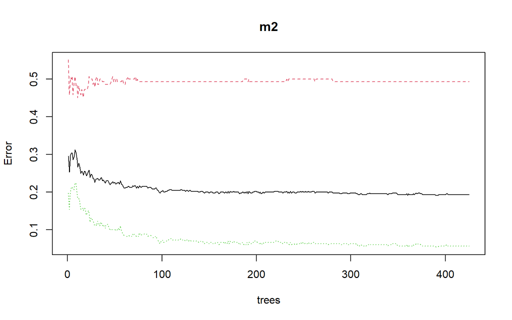

```r
plot(m2)
```